# Ford_Go_Bike Trip Duration vs User Type and Week Days

## by Uzedu Omoyemen Frances

## Investigation Overview

> In this dataset investigation, I looked at the Bike Trip duration how it cuts across the user types and also against different days of the week. The main variables of interest were the Trip duration, user type, and days of the week the bike was rented.

## Dataset Overview

> This data set includes information about individual rides made in a bike-sharing system covering the greater San Francisco Bay area. This dataset contains about 184,000 entries and includes variables such as Bike trip duration, User type, gender, start time, end time, End Station Latitude, End Station Longitude, Start Station Latitude, Start Station Longitude and after some cleaning process was carried out 174,000 rows were left.

## Distribution of Bike Trips Duration in seconds

Time spent on a trip for most rides was about 10 minutes (600 seconds).

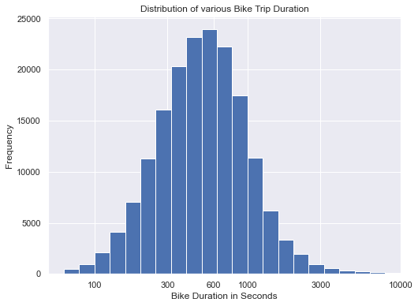

## Distribution of User Type

We have more subscribers than customers. The customers are temporary or one-time users while subscribers are members or frequent users.

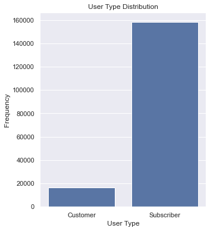

## Distribution of Days bikes were rented

Most trips were taken during the week especially Thursdays and Tuesdays unlike weekend.

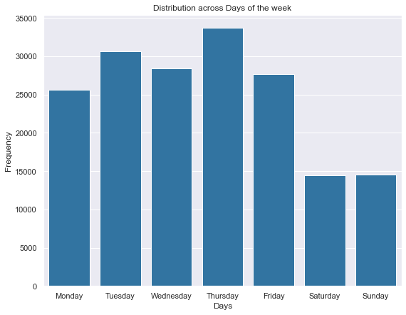

## Distribution of Bike trip vs User Type

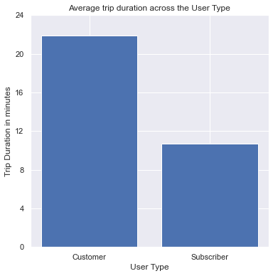

## Distribution of Bike trips vs Days of the week

More time was spent on trips during the weekends unlike the weekedays

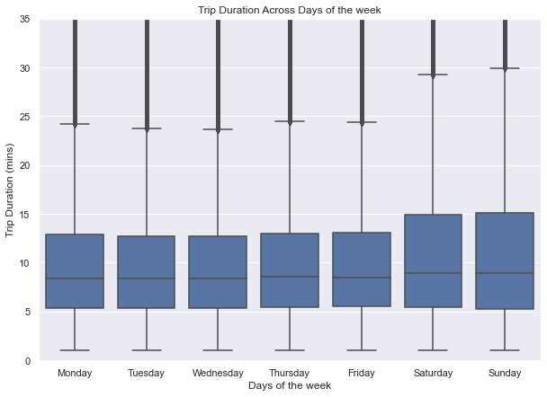

## Distribution of Bike trip vs User type vs Days of the week

Customers generally travel long distance especially during weekends, whereas the subscribers take short journeys regardless of what day of the week it is.

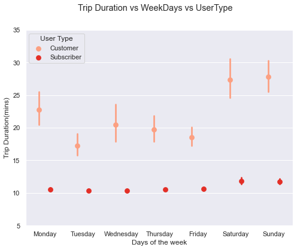